# Combine Bench Over Time

Author

Affiliation

BMS

University of Scranton

# Executive Summary

# Background

[The National Football League](https://en.wikipedia.org/wiki/National_Football_League) (NFL) is a professional athletics organization consisting of 32 teams equally separated into two conferences, with each conference consisting of 4-team divisions. Every year in March, the NFL hosts a recruiting event called the [NFL Draft](https://en.wikipedia.org/wiki/National_Football_League_Draft). In the NFL Draft, every NFL Team has the opportunity to have an exclusive right to negotiate with prospective players and sign them to their team. To assess the talent and ability of each player, players will showcase their skills in front of NFL coaches, general managers, and scouting officials at the [NFL Scouting Combine](https://en.wikipedia.org/wiki/NFL_Scouting_Combine). In the Combine, players participate in a range of events displaying their skills, including a 40-yard dash (Shown in Figure 1), vertical jump test, broad jump test, and the bench press test, which will be the focus of this project.

[figure not shown]

Figure 1: Player Sprinting the Forty Yard Dash at the NFL Scouting Combine, image from (“Washington’s John Ross sets 40-yard dash record at NFL Scouting Combine” https://www.wkyc.com/article/sports/nfl/nfl-draft/washingtons-john-ross-sets-40-yard-dash-record-at-nfl-scouting-combine/95-419799888)

## Initial Research Question

Before my exploratory data analysis, my first research question was to investigate how a player’s performance in their NFL Combine appearance impacts the number of NFL teams they will play on throughout their careers. NFL players can make appearances on several teams throughout their careers, as the result of contract expiration, a transaction (trade) between two teams, or a release of a player to Free-Agency, colloquially known as dropping a player. However, the data set I chose to explore did not record every team each individual player was ever a part of. Instead, it only contained the first team the player was a member of. As a result, I amended my research question to investigate an attribute the data set had plentiful data on, which is the number of bench press repetitions each Combine participant could perform during their showcase. **Hence, I would like to know which biometrics of Combine participants are the best predictors of the number of bench press repetitions one can perform?**

## Approach to Research

In order to address my initial research question, I will study the relationships between the number of bench press repetitions and various relevant biometrics collected during the Combine. In the NFL Scouting Combine, each player is assessed for the number of repetitions of a 225-lb bench press one can perform lying down on a bench similar to those found in commercial gyms, and depicted in Figure 2. The main part of this project will be assessing how the number of bench press repetitions has increased from 1999 to 2015, since those are the years the data set includes data for.

[figure not shown]

Figure 2: Official Bench Press bench used in the NFL Scouting Combine, image from (“NFL Combine: Which player did the most bench-press reps on Friday?” https://www.al.com/sports/2019/03/nfl-combine-which-player-did-the-most-bench-press-reps-on-friday.html)

# Data Collection and Documentation

To address my research question, I will use the data set [1999 to 2015 Combine Data](https://nflsavant.com/about.php), which was compiled by Daren Willman using “publicly-available NFL play-by-play data on the internet” (Willman). I obtained this data set as a CSV file from [NFLSavant.com](https://nflsavant.com), a free website designed to provide NFL data through an accessible user interface. Daren Willman curates and updates this data set to allow anyone to see and use this data. The data set I am using samples exclusively those who participated in the NFL Combine from 1999 to 2015, totaling nearly 4,946 players.

## Combine Data

The data from the link provided by Willman’s website is in `.csv` format. For this project, I am storing the data as a `.csv` locally in this project’s repository. The data in its original form is tabular, and initially included 4,947 rows and 26 columns. Each column contains attributes of each athlete, including biometrics like their `height`, `weight`, `wingspan`, and athletic metrics including `bench` (number of repitions of 225 lb bench press), `vertical` (jumping height), and `fortyyd` (40 yd sprint time). Each row is a unique player which participated in the NFL combine. This data set, shown in Table 1 is self-contained, as there are no external resources or dependencies required to analyze this data set.

```r
condensed_combine %>%
  select(name, position, heightinchestotal, weight, arms) %>%
  head(5) %>%
  kable()
```

Table 1: Select columns of the first five rows of the cleaned and condensed `combine` data set.

| name | position | heightinchestotal | weight | arms |
| --- | --- | --- | --- | --- |
| Ameer Abdullah | RB | 69 | 205 | 0 |
| Nelson Agholor | WR | 72 | 198 | 0 |
| Jay Ajayi | RB | 72 | 221 | 0 |
| Kwon Alexander | LB | 73 | 227 | 0 |
| Mario Alford | WR | 68 | 180 | 0 |

### Cleaning Combine Data

The only errors present in this data set were two rows which appeared to have their values offset by two columns, making them unusable for exploratory data analysis. The only cleaning of the `combine` data set was to remove the two previously mentioned problematic rows. I simply ran a command to `filter()` out the two rows where the player’s `height` was equal to `NA`, and stored the result into a new data frame, `clean_combine`, shown in Table 2.

```r
clean_combine <- combine %>%
  filter(!is.na(heightfeet))

clean_combine %>%
  select(name, position, heightinchestotal, weight, arms) %>%
  head(5) %>%
  kable()
```

Table 2: Select columns of the first five rows of cleaned `combine` data set.

| name | position | heightinchestotal | weight | arms |
| --- | --- | --- | --- | --- |
| Ameer Abdullah | RB | 69 | 205 | 0 |
| Nelson Agholor | WR | 72 | 198 | 0 |
| Jay Ajayi | RB | 72 | 221 | 0 |
| Kwon Alexander | OLB | 73 | 227 | 0 |
| Mario Alford | WR | 68 | 180 | 0 |

```r
write_csv(clean_combine, "../data/clean_combine.csv")
```

# Exploratory Data Analysis

## Potential Response Variables

I can answer this question by categorizing the rows according to the year, then plotting a histogram of the `bench` variable which contains values from rows with a specified year. In other words, I can make seventeen plots, shown in Figure 3 which counts the possible number of bench press reps and how often they occur.

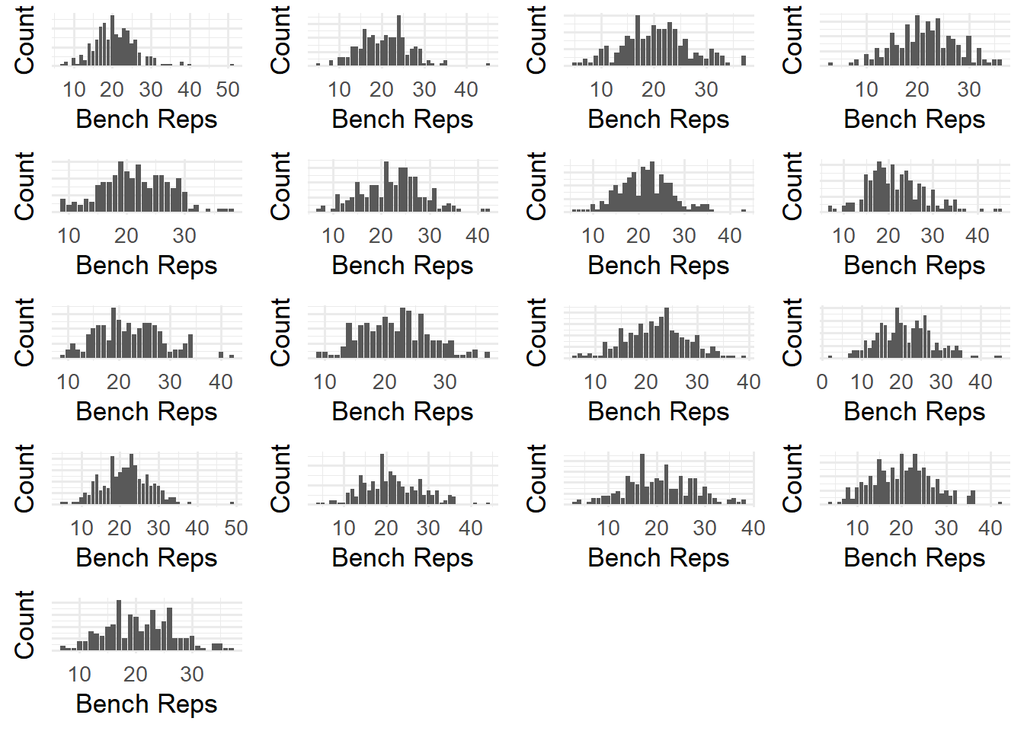

Figure 3: Histogram for every year included in the data set of the total occurrences of every value of bench press repetitions.

```r
plot_bench <- function(yr) {
  condensed_combine %>%
    filter(bench > 0 & year == yr) %>%
    ggplot(aes(x = bench)) +
    geom_bar() +
    theme(axis.text.y=element_blank()) +
    labs(x = "Bench Reps", y = "Count")
}

bench_reps_per_year <- map(1999:2015, plot_bench)

ggarrange(plotlist = bench_reps_per_year, ncol = 4, nrow = 5)
```

All of these graphs suggest that the average is some value less than or equal to 20 reps. To verify this claim, I will plot the average number of bench press reps of all players for every year in Figure 4.

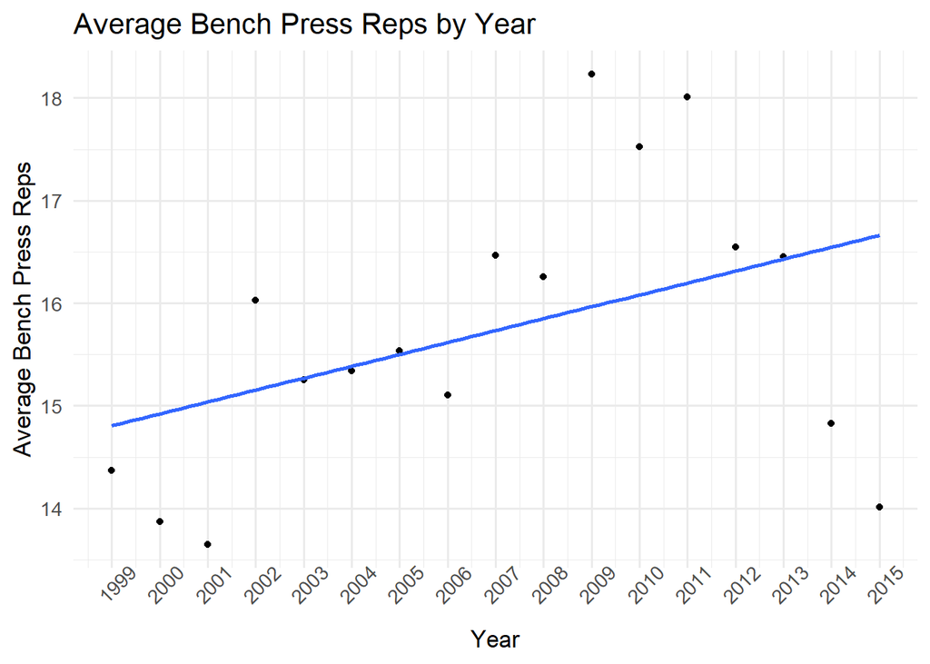

Figure 4: Exploratory plot showing the average number of bench press repetitions from 1999 to 2015.

```r
condensed_combine %>%
  group_by(year) %>%
  summarise(mean_bench = mean(bench, na.rm = TRUE)) %>%
  ggplot(aes(x = year, y = mean_bench)) +
  geom_point() +
  scale_x_continuous(breaks = 1999:2015) +
  geom_smooth(method=lm, se=FALSE) +
  theme(axis.text.x = element_text(angle=45)) +
  labs(x = "Year", y = "Average Bench Press Reps", title = "Average Bench Press Reps by Year")
```

This graph supports my conclusion that the number of bench press reps was some value under 20. Furthermore, this graph shows that the average number of bench press reps is trending upward from 1999 to 2015.

## Potential Predictor Variables

As previously stated, I will only consider statistics about a player which would have an impact on their bench press repetitions. Biometrics I consider to be relevant are ones which impact the parts of the body directly involved in the bench press movement. With this criteria, I will select three variables to study, which include a player’s weight, arm length, and height. Other statistics included in the data set, like the 40-yard dash time and broad jump distance, I would not consider to be relevant because those tests do not use parts of the body which are used in the motion of performing a bench press.

### Player Weight

A player’s weight will have an impact on the number of bench press repetitions a player can perform because the more muscle mass players have, the more likely it is for them to perform a higher number of bench press repetitions compared to those who have less muscle mass. Figure 5 will give us an idea of what types of players are included in this data set.

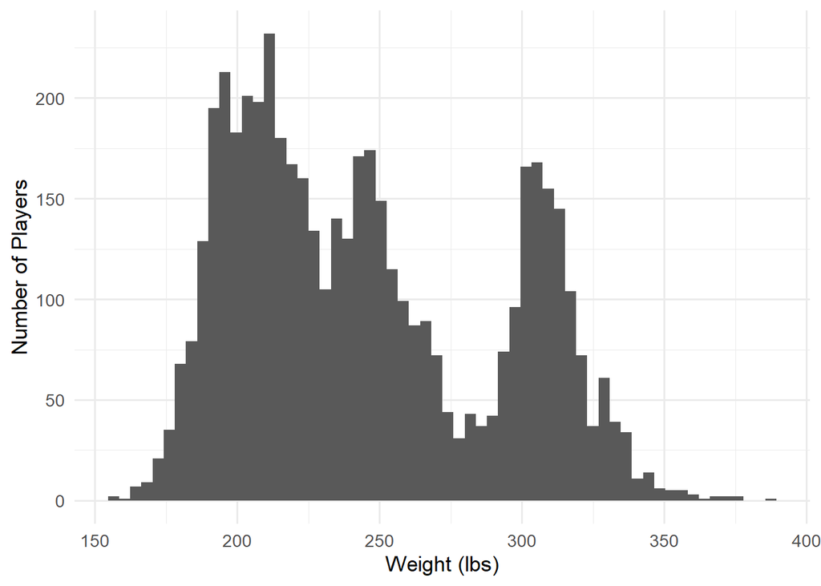

Figure 5: Histogram of combine participant weight values.

```r
condensed_combine %>%
  ggplot(aes(x = weight)) +
  geom_histogram(bins=60) +
  labs(x = "Weight (lbs)", y = "Number of Players")
```

Since this project is looking at the relationship between weight and number of bench press repetitions over several years, it is useful to understand how the average weight of NFL players has changed from 1999 to 2015. We can observe this relationship in Figure 6

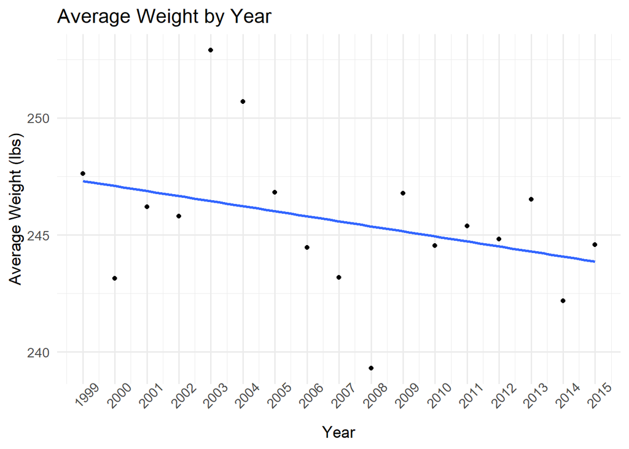

Figure 6: Exploratory plot showing the average weight of every player from 1999 to 2015.

```r
condensed_combine %>%
  group_by(year) %>%
  summarise(mean_weight = mean(weight, na.rm = TRUE)) %>%
  ggplot(aes(x = year, y = mean_weight)) +
  geom_point() +
  scale_x_continuous(breaks = 1999:2015) +
  geom_smooth(method=lm, se=FALSE) +
  theme(axis.text.x = element_text(angle=45)) +
  labs(x = "Year", y = "Average Weight (lbs)", title = "Average Weight by Year")
```

The negative relationship between average weight and time is interesting for several reasons. First, it is important to consider that the roster size for each NFL team was recently increased to 53 (46 active and 7 inactive) players in 2011. This recent increase in roster could possibly lead to an influx of “lighter” specialist players into the league ([https://operations.nfl.com/inside-football-ops/players-legends/evolution-of-the-nfl-player/#:~:text=Over%20time%2C%20teams’%20roster%20sizes,inactive%20players%20before%20each%20game](https://operations.nfl.com/inside-football-ops/players-legends/evolution-of-the-nfl-player/#:~:text=Over%20time%2C%20teams'%20roster%20sizes,inactive%20players%20before%20each%20game.)).

### Player Height

Similar to a player’s weight, their height, summarized in Figure 7 could have an impact on the number of bench press repetitions they may be able to perform. This biometric is interesting because players with different heights will have different centers of mass. Additionally, shorter players tend to have shorter arms, which could impact a player’s number of bench press repetitions.

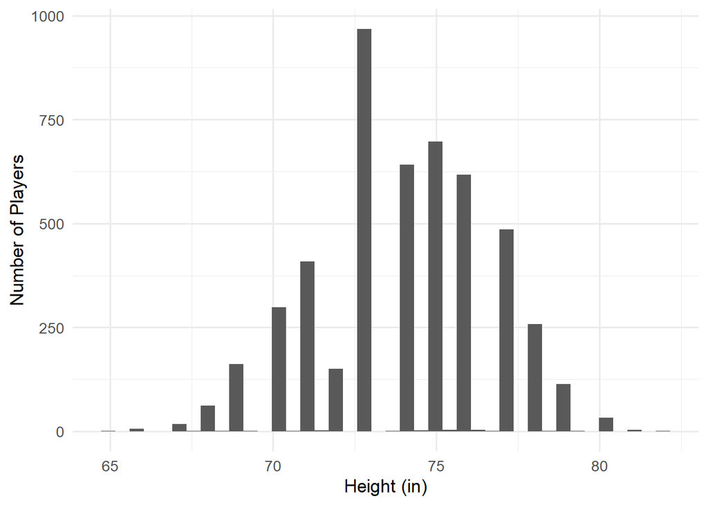

Figure 7: Histogram of combine participant heights.

```r
condensed_combine %>%
  ggplot(aes(x = heightinchestotal)) +
  geom_histogram(bins=40)+
  labs(x = "Height (in)", y = "Number of Players")
```

Similarly to the scenario with the weight, a possible explanation for the decrease in the average height shown in Figure 8 could be the increased amount of players teams can roster. The average could be decreasing due to the fact that NFL teams can have more players on their rosters, but there has been no increase to the number of players on the field during a game, suggesting that teams are likely to fill those roster spots with players who are shorter on average.

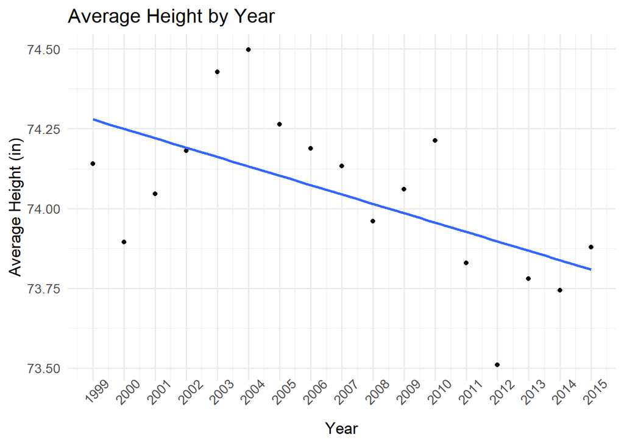

Figure 8: Exploratory plot showing the average height of every player from 1999 to 2015.

```r
condensed_combine %>%
  group_by(year) %>%
  summarise(mean_heightinchestotal = mean(heightinchestotal, na.rm = TRUE)) %>%
  ggplot(aes(x = year, y = mean_heightinchestotal)) +
  geom_point() +
  scale_x_continuous(breaks = 1999:2015) +
  geom_smooth(method=lm, se=FALSE) +
  theme(axis.text.x = element_text(angle=45)) +
  labs(x = "Year", y = "Average Height (in)", title = "Average Height by Year")
```

### Player Arm Length

A player’s arm length is most likely the most significant predictor of the number of bench press repetitions a player can perform because there is a direct relationship between the length of a player’s arm and the distance a player needs to move the barbell to complete a single repetition of a 225-lb bench press. Hence, it is logical to conclude that the shorter a player’s arms are, the more repetitions of bench press a player is potentially capable of performing. Figure 9 displays the range and number of arm length values included in this data set.

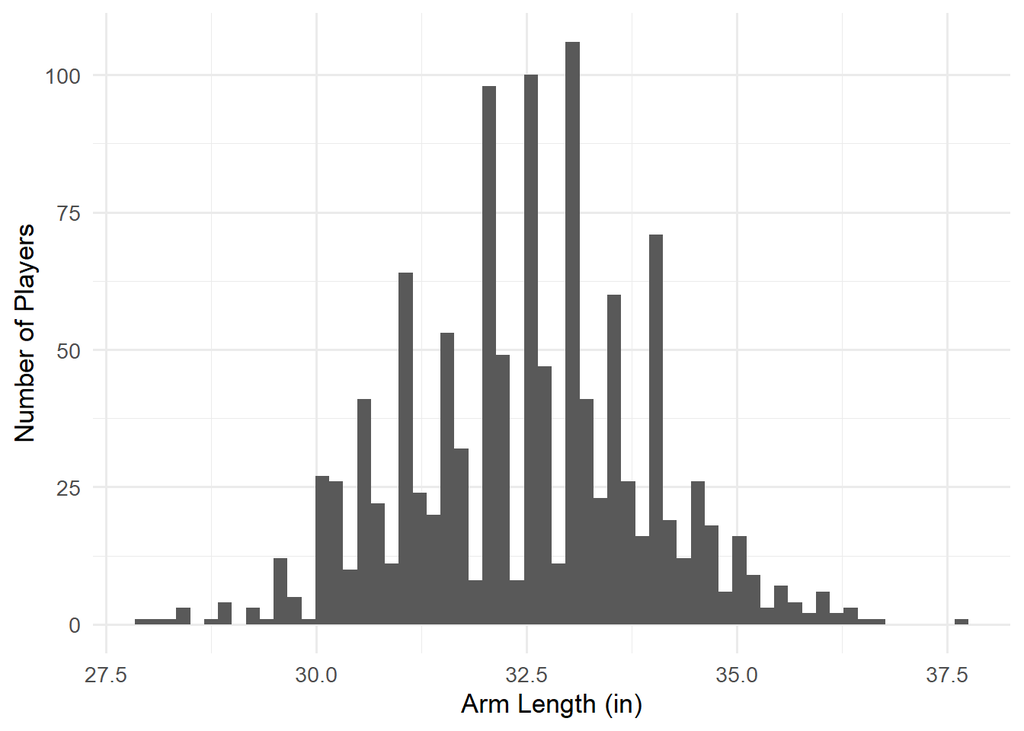

Figure 9: Histogram of combine participant arm lengths.

```r
condensed_combine %>%
  filter(arms != 0) %>%
  ggplot(aes(x = arms)) +
  geom_histogram(bins = 60) +
  labs(x = "Arm Length (in)", y = "Number of Players")
```

Upon further inspection in Figure 10, it is clear that the data accounting for the length of Combine participant’s arms is incomplete, as filtering out all observations which have `0` as the `arms` value completely excludes 1999, 2000, 2001, 2003, 2014, and 2015. The relationship in this graph, similar to the previous two predictor variables, could possibly be explained by the increased roster size.

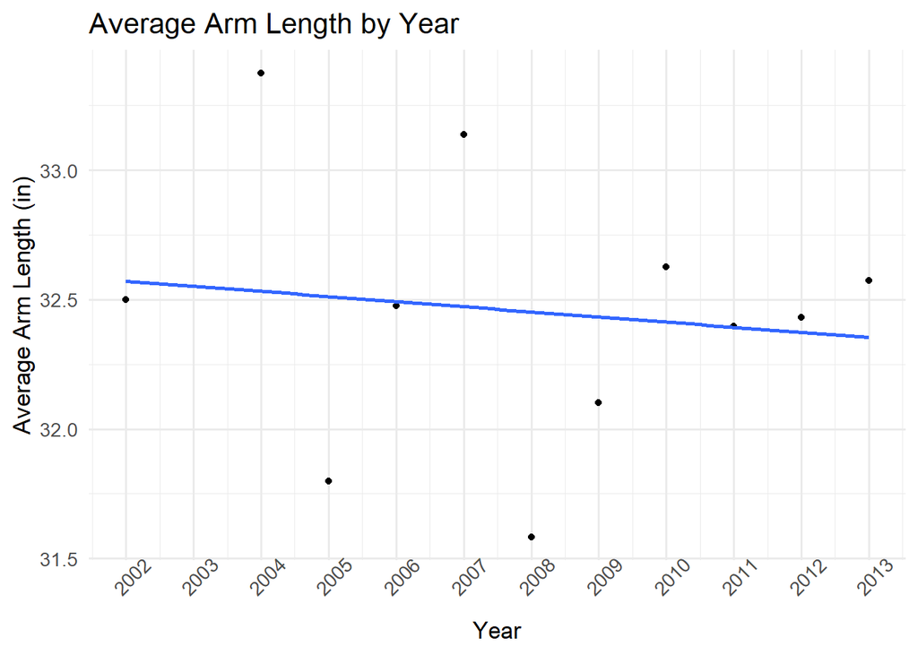

Figure 10: Exploratory plot showing the average arm length of every player from 1999 to 2015.

```r
condensed_combine %>%
  filter(arms != 0) %>%
  group_by(year) %>%
  summarise(mean_arms = mean(arms, na.rm = TRUE)) %>%
  ggplot(aes(x = year, y = mean_arms)) +
  geom_point() +
  scale_x_continuous(breaks = 1999:2015) +
  geom_smooth(method=lm, se=FALSE) +
  theme(axis.text.x = element_text(angle=45)) +
  labs(x = "Year", y = "Average Arm Length (in)", title = "Average Arm Length by Year")
```

## Variable Relationships

### Player Weight and Number of Repetitions

To explore the relationship between these two variables, I will start with plotting graphs relating every player’s weight to their number of bench press repetitions. One graph for each year between 1999 and 2015, shown in Figure 11.

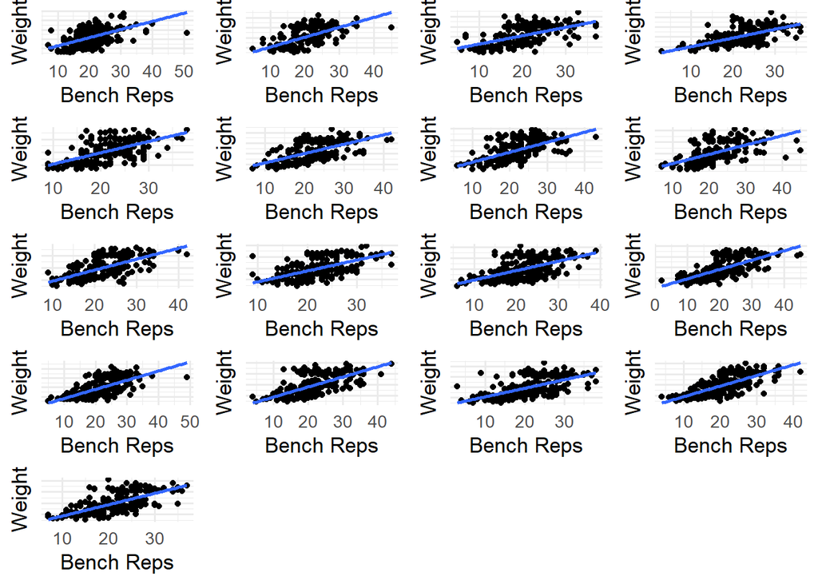

Figure 11: Plot showing relationship between number of bench press repetitions and weight, one plot for each year included in the data set. Weight is in units of pounds (lbs).

```r
bench_weight <- function(yr) {
  condensed_combine %>%
    filter(bench > 0 & year == yr) %>%
    ggplot(aes(x = bench, y = weight)) +
    geom_point() +
    geom_smooth(method=lm, se=FALSE) +
    theme(axis.text.y=element_blank()) +
    labs(x = "Bench Reps", y = "Weight")
}

bench_weight_per_year <- map(1999:2015, bench_weight)

ggarrange(plotlist = bench_weight_per_year, ncol = 4, nrow = 5)
```

Each graph, along with its own line of best fit, demonstrate that there is a positive relationship between a combine participant’s body weight and their number of bench press repetitions. To summarize this data, I will create Figure 12 graphing the relationship between the average weight of players for each number of bench press repetitions performed.

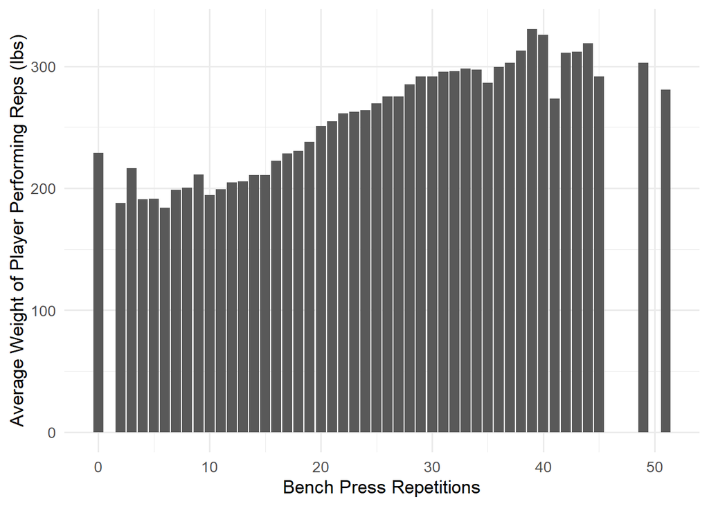

Figure 12: Graph plotting the relationship between average weight and number of repetitions of bench press.

```r
condensed_combine %>%
  filter(position != "OC") %>%
  group_by(bench) %>%
  summarise(mean_weight = mean(weight, na.rm = TRUE)) %>%
  ggplot(aes(x = bench, y = mean_weight)) +
  geom_bar(stat = "identity") +
  labs(x = "Bench Press Repetitions", y = "Average Weight of Player Performing Reps (lbs)")
```

This graph suggests that on average, players who perform more bench press repetitions tend to be heavier than those who perform a fewer number of bench press repetitions.

### Player Height and Number of Repetitions

To explore the relationship between these two variables, I will take a similar approach to exploring the previous relationship, by starting with plotting graphs relating every player’s height to their number of bench press repetitions. One graph for each year between 1999 and 2015 is shown in Figure 13.

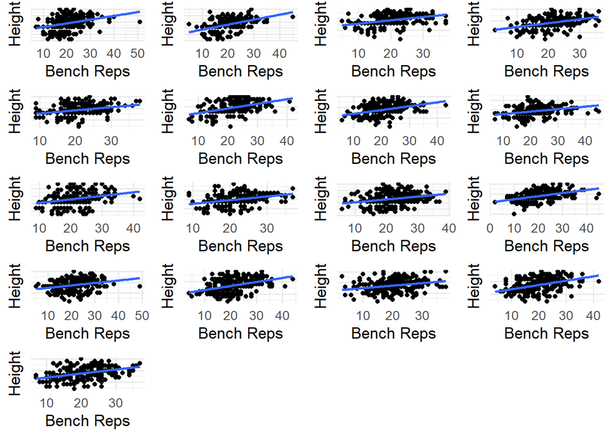

Figure 13: Plot showing relationship between number of bench press repetitions and height, one plot for each year included in the data set. Height is in units of inches (in).

```r
bench_height <- function(yr) {
  condensed_combine %>%
    filter(bench > 0 & year == yr & heightinchestotal > 0) %>%
    ggplot(aes(x = bench, y = heightinchestotal)) +
    geom_point() +
    geom_smooth(method=lm, se=FALSE) +
    theme(axis.text.y=element_blank()) +
    labs(x = "Bench Reps", y = "Height")
}

bench_height_per_year <- map(1999:2015, bench_height)

ggarrange(plotlist = bench_height_per_year, ncol = 4, nrow = 5)
```

Each graph, along with its own line of best fit, demonstrate that there is a positive relationship between a combine participant’s height and their number of bench press repetitions. To summarize this data, I will create the plot shown in Figure 14 graphing the relationship between the average height of players for each number of bench press repetitions performed.

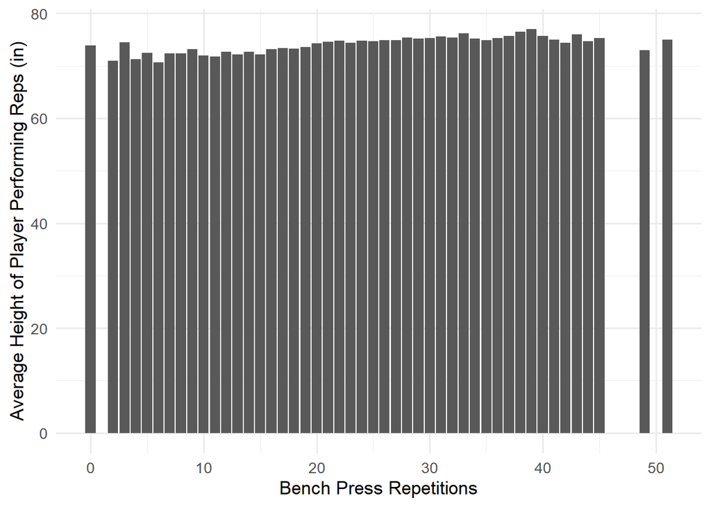

Figure 14: Graph plotting the relationship between average height and number of repetitions of bench press.

```r
condensed_combine %>%
  filter(position != "OC") %>%
  group_by(bench) %>%
  summarise(mean_heightinchestotal = mean(heightinchestotal, na.rm = TRUE)) %>%
  ggplot(aes(x = bench, y = mean_heightinchestotal)) +
  geom_bar(stat = "identity") +
  labs(x = "Bench Press Repetitions", y = "Average Height of Player Performing Reps (in)")
```

This graph shows that there is little correlation between the number of bench press repetitions a player can perform and the average height of a player who can perform that specific number of bench press repetitions.

### Player Arm Length and Number of Repetitions

The body part directly involved with performing the exercise is the arm, which travels up and down in a path parallel to the ground. However, this distance traveled is different for every player because every player’s arm length is different. I will create a plot, shown in Figure 15 to investigate the potential relationship between a player’s wingspan and their number of bench press reps.

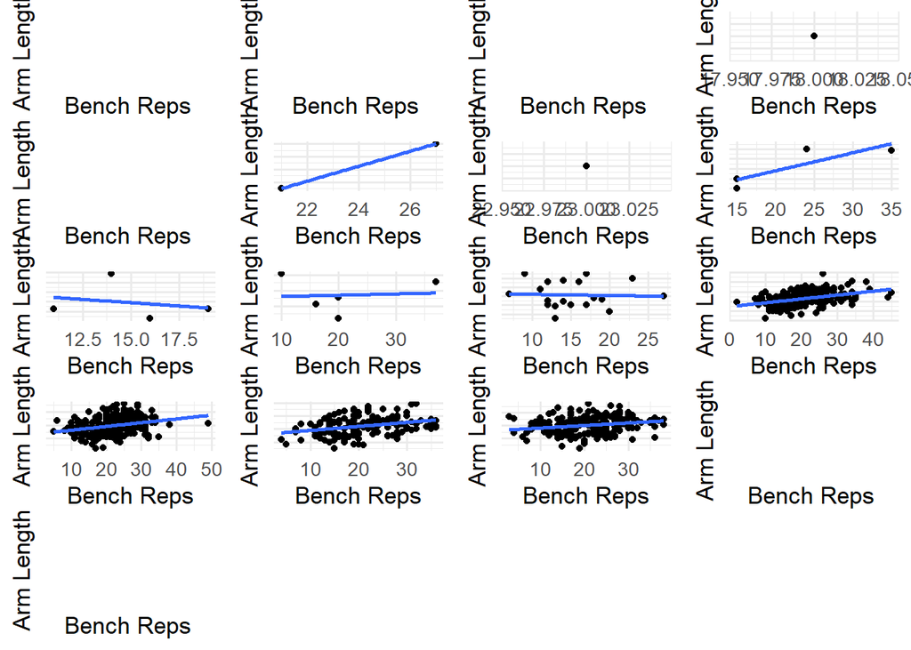

```r
bench_arms <- function(yr) {
  condensed_combine %>%
    filter(bench > 0 & year == yr & position != "K" & arms != 0) %>%
    ggplot(aes(x = bench, y = arms)) +
    geom_point() +
    geom_smooth(method=lm, se=FALSE) +
    theme(axis.text.y=element_blank()) +
    labs(x = "Bench Reps", y = "Arm Length")
}

bench_height_per_year <- map(1999:2015, bench_arms)

ggarrange(plotlist = bench_height_per_year, ncol = 4, nrow = 5)
```

In the case of my data set, it is evident that the arm length data is incomplete, and will likely remain so for the foreseeable future. When plotting the average arm length of players who perform specific number of bench press repetitions, in Figure 16, it is initially unclear as if there exists a relationship between these two variables.

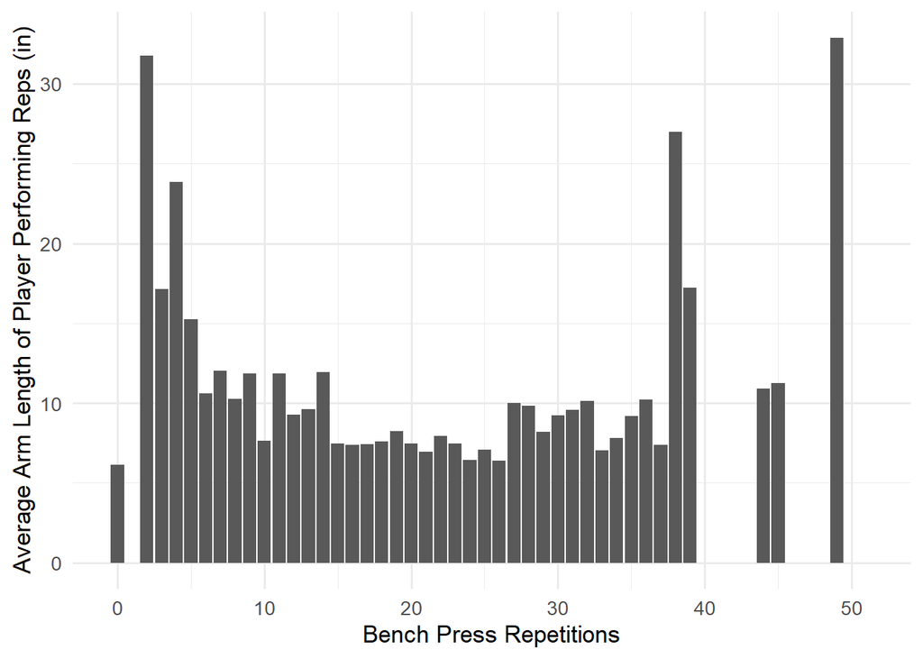

Figure 16: Graph plotting the relationship between average arm length and number of repetitions of bench press.

```r
condensed_combine %>%
  filter(position != "OC") %>%
  group_by(bench) %>%
  summarise(mean_arms = mean(arms, na.rm = TRUE)) %>%
  ggplot(aes(x = bench, y = mean_arms)) +
  geom_bar(stat = "identity") +
  labs(x = "Bench Press Repetitions", y = "Average Arm Length of Player Performing Reps (in)")
```

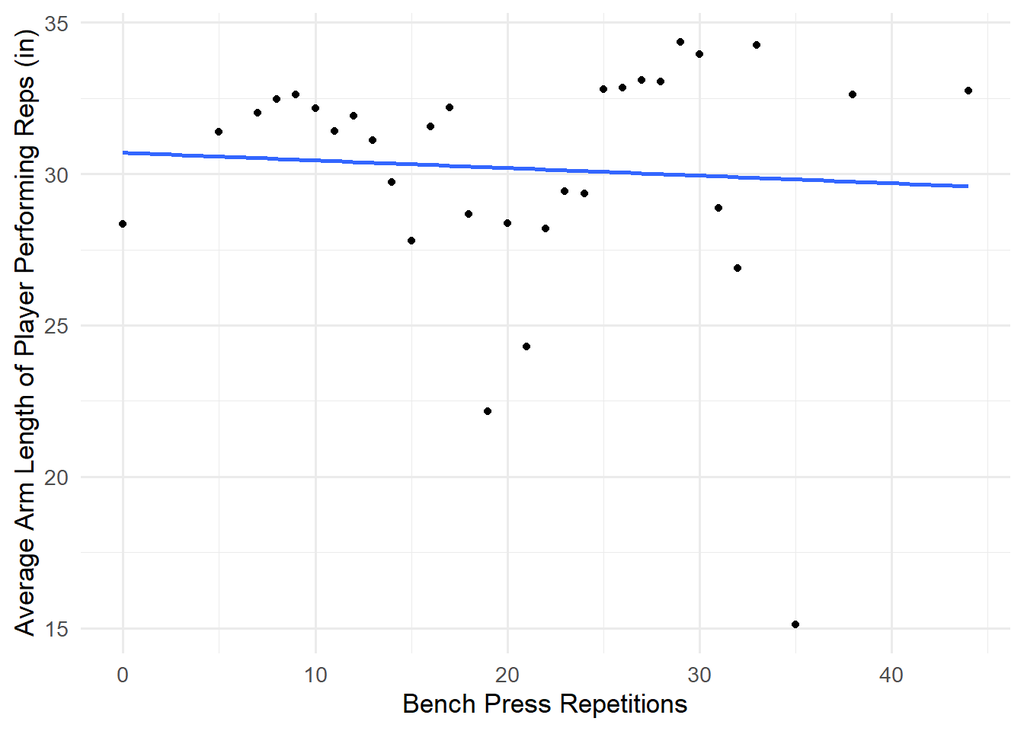

Figure 17: Scatter plot with trend line showing the relationship between average arm length and number of repetitions of bench press.

```r
condensed_combine %>%
  filter(position != "OC" & year == c(2010, 2011, 2012, 2013)) %>%
  group_by(bench) %>%
  summarise(mean_arms = mean(arms, na.rm = TRUE)) %>%
  ggplot(aes(x = bench, y = mean_arms)) +
  geom_point()+
  geom_smooth(method=lm, se=FALSE) +
  labs(x = "Bench Press Repetitions", y = "Average Arm Length of Player Performing Reps (in)")
```

## Further Exploratory Analysis

### Is the number of bench press repetitions different depending on a player’s position?

Many football spectators know that football is a game where individuals play specific positions, and hence have training and nutrition regimens designed to make those players better at their positions. A consequence of this is that lineman are significantly heavier than their backfield counterparts. This observation serves as the main inspiration for this question.

To answer this question, I will plot the average number of bench press repetitions for players, grouped by the position of the player in Figure 18.

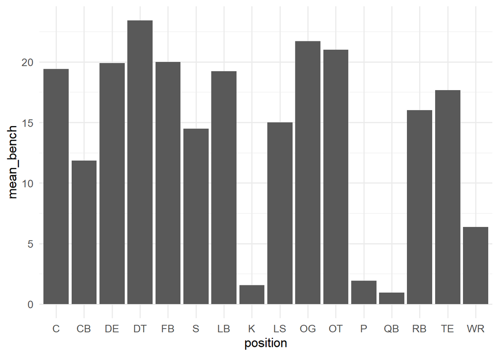

Figure 18: Histogram showing the average number of bench press repetitions for every player position, for all years in the data set.

```r
condensed_combine %>%
  filter(position != "OC") %>%
  group_by(position) %>%
  summarise(mean_bench = mean(bench, na.rm = TRUE)) %>%
  ggplot(aes(x = position, y = mean_bench)) +
  geom_bar(stat = "identity")
```

This graph suggests that players playing different positions on a football team have different bench press repetition averages.

## Conclusion

# Models

## Linear Regression

For the variables I have explored, I will use a linear regression, an example of which shown in Figure 19, to assess whether there is a relationship between the number of bench press repetitions a player can perform and several biometrics, including weight, height, and arm length.

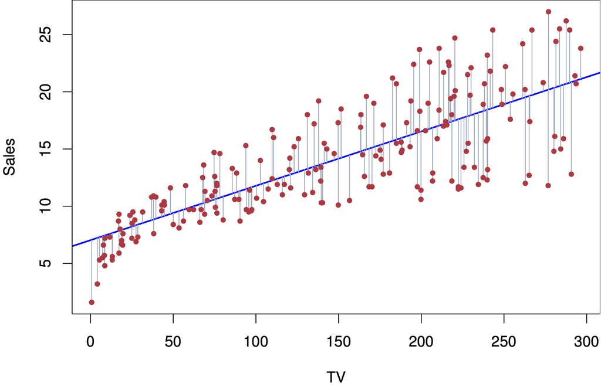

Figure 19: An example of a linear regression, image from (“Simple linear regression” https://web.stanford.edu/class/stats202/notes/Linear-regression/Simple-linear-regression.html)

## KNN

Another model, shown in Figure 20 I will use is the K-Nearest-Neighbors classification model, in order to investigate the potential relationship between a player’s position and their combine statistics, including bench, height, weight, and arm length.

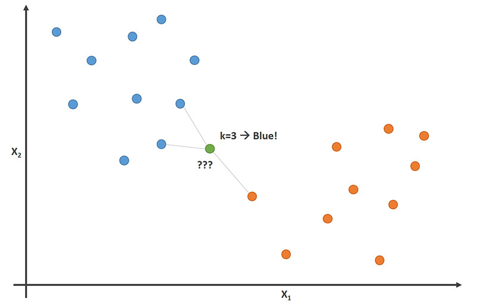

Figure 20: An example of a KNN Classification, image from (“K-Nearest Neighbors: A Simple Machine Learning Algorithm” https://rapidminer.com/blog/k-nearest-neighbors-laziest-machine-learning-technique/)

# Model Results

## Predictors of Number of Repetitions

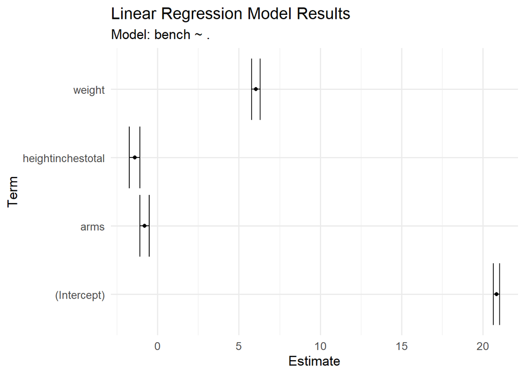

Figure 21: Linear regression predicting the number of repetitions of bench press a player can perform based on their height, weight, and arm length.

```r
# set seed for reproducability
set.seed(4133)

# load the combine dataset (should already be loaded from previous chunks)
combine_nums <- condensed_combine %>%
  select(bench, arms, heightinchestotal, weight) %>%
  filter(bench != 0, arms != 0, heightinchestotal != 0, weight != 0)

data(combine_nums)

# create a training and testing split
combine_split <- initial_split(combine_nums, prop = 0.8)

# create a training and testing dataset
combine_training <- training(combine_split)
combine_testing <- testing(combine_split)

# create a recipe for preprocessing
combine_recipe <- recipe(bench ~ ., data = combine_training) %>%
  step_center(all_predictors()) %>%
  step_scale(all_predictors())

# create a linear regression model
lm_spec <- linear_reg() %>%
  set_engine("lm")

# fit the model
lm_fit <- workflow() %>%
  add_recipe(combine_recipe) %>%
  add_model(lm_spec) %>%
  fit(data = combine_training)

# make predictions
lm_pred <- predict(lm_fit, combine_testing) %>%
  bind_cols(combine_testing)

# evaluate the model
lm_eval <- lm_pred %>%
  metrics(truth = bench, estimate = .pred) %>%
  bind_rows(
    lm_pred %>%
      rsq(truth = bench, estimate = .pred) %>%
      mutate(metric = "rsq")
  )

# tidy the model results
lm_tidy <- tidy(lm_fit)

# visualize the model results
lm_tidy %>%
  ggplot(aes(x = term, y = estimate)) +
  geom_point() +
  geom_errorbar(aes(ymin = estimate - std.error, ymax = estimate + std.error)) +
  coord_flip() +
  labs(
    title = "Linear Regression Model Results",
    subtitle = "Model: bench ~ .",
    x = "Term",
    y = "Estimate"
  )
```

## Predictors of Player Position

These tables and figures display a KNN classification model which characterizes what position a combine participant is most likely to be playing given a number of biometrics, including weight, wingspan, hand size, and multiple athletic statistics including ten, twenty, and forty yard dash times, three cone and twenty yard shuttle times, jump height, jump distance, and number of bench press repetitions. With the given data set, removing all rows with any values of zero would reduce the number of rows to an abysmally low number where no meaningful conclusions could be made. Since values of zero are included in this model, it is impossible to confirm or deny and evidence for/against a relationship between where a player plays on the field and the previously mentioned biometrics. This model will categorize players based on the previously mentioned biometrics by where they would play on the field, which includes the offensive line, defensive line, offensive backfield, defensive backfield, and special teams.

```r
generalized_combine <- condensed_combine %>%
  mutate(position = fct_collapse(position,
    "O-Line" = c("OG", "OT", "C"),
    "O-2ry" = c("FB", "QB", "RB", "TE", "WR"),
    "D-Line" = c("DT", "DE"),
    "D-2ry" = c("CB", "S", "LB"),
    "Special" = c("K", "P", "LS"),
  ))

#glimpse(generalized_combine)

# set seed for reproducability
set.seed(4133)

# load the combine dataset (should already be loaded from previous chunks)
combine_pos <- generalized_combine %>%
  select(heightinchestotal, weight, arms, hands, fortyyd, twentyyd, tenyd, twentyss, threecone, vertical, broad, bench, position) #%>%
  #filter(weight != 0, arms != 0, hands != 0, fortyyd != 0, twentyyd != 0, tenyd != 0, twentyss != 0, threecone != 0, vertical != 0, broad != 0, bench != 0)

# glimpse(combine_pos)

# create a training and testing split
combine_pos_split <- initial_split(combine_pos, prop = 0.8)

# create a training and testing dataset
combine_pos_training <- training(combine_pos_split)
combine_pos_testing <- testing(combine_pos_split)

# every predictor adds a dimension, and I have too many of them.

position_rec <- recipe(position ~ heightinchestotal + weight + arms + hands + fortyyd + twentyyd + tenyd + twentyss + threecone + vertical + broad + bench,
                       data = combine_pos_training) %>%
  step_normalize(all_numeric_predictors())

position_spec <- nearest_neighbor(neighbors = 5) %>%
  set_engine("kknn") %>%
  set_mode("classification")

#neighbors = tune()

#follow lesson 8 example 3

position_wf <- workflow() %>%
  add_recipe(position_rec) %>%
  add_model(position_spec)

position_fit <- fit(position_wf,combine_pos_training)
```

Figure 22 shows the results of the KNN classification with the test data which was previously left out of the training set.

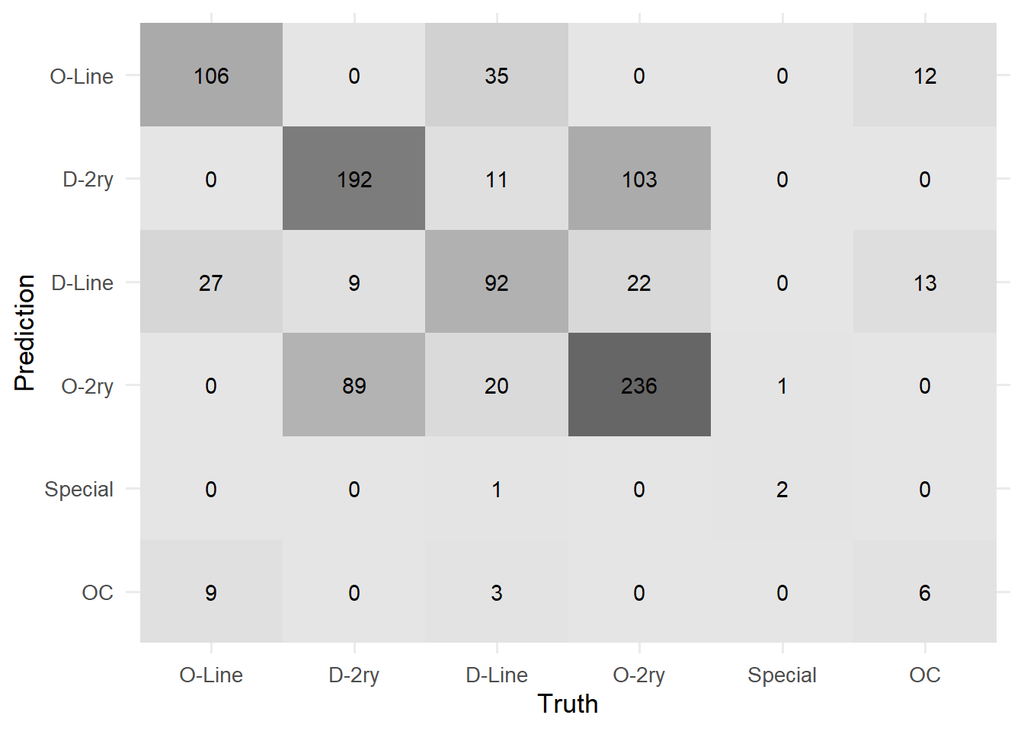

Figure 22: Truth table of the K-Nearest-Neighbors classification where the values on the diagonals are successful identifications, and any others are unsuccessful identifications.

```r
position_fit %>%
  predict(combine_pos_testing) %>%
  cbind(combine_pos_testing) %>%
  conf_mat(position,.pred_class) %>%
  autoplot(type = "heatmap")
```

Table 3 shows the accuracy of the model as a percentage, calculated by dividing the number of successful identifications by the total number of trials.

```r
position_fit %>%
  predict(combine_pos_testing) %>%
  cbind(combine_pos_testing) %>%
  accuracy(position,.pred_class) %>%
  kable()
```

Table 3: Accuracy of the K-Nearest-Neighbors model, displayed in the `.estimate` column.

| .metric | .estimator | .estimate |
| --- | --- | --- |
| accuracy | multiclass | 0.6410516 |

Figure 23 graphs which players the model successfully and unsuccessfully identified the positions of.

[figure not shown]

```r
position_fit %>%
  predict(combine_pos_testing) %>%
  cbind(combine_pos_testing) %>%
  mutate(prediction = ifelse(position == .pred_class, "Correct", "Incorrect")) %>%
  ggplot(aes(x = fortyyd, y = weight, color = prediction)) +
  geom_point() +
  theme(legend.position = "bottom") +
  scale_color_colorblind() +
  labs(x = "Weight (lb)", y = "Forty Yard Dash (yd)")
```

## KNN Model Results

# Conclusions

In this report, I analyzed the relationships between number of bench press repetitions, player weight, player height, and player arm length for those who participated in the NFL Scouting Combine from the years 1999 to 2015. Despite the limited arm length data, there is evidence to suggest that there is a relationship between reps and all three predictors because of the low standard deviation. This is likely because these three predictors have the most impact upon the movement of the barbell, the rod holding the weights, and the player’s ability to repeatedly move the barbell. A player’s weight could factor into how much muscle mass they have, contributing to the increased strength of the player. Player’s height could influence whether more mass is stored in muscle tissue, in the case with shorter players, or in skeletal tissue, in the case with taller players. Finally and most obviously, a player’s arm length directly impacts their ability to move the barbell, because those with shorter arms need to make the bar travel a shorter distance than those with longer arms. The decreased travel time reduces the amount of time the pectoral muscles, highlighted in Figure 24 are under tension, which reduces the amount of fatigue they experience. In the future, it would be helpful to include more complete data for players’ arm length, as well as more recent Combine data, ideally including the Combine most recent to the time of writing.

[figure not shown]

Figure 24: Diagram highlighting muscles worked when performing a bench press. The left diagram depicts a person in the middle, or at the bottom, of the press. The right diagram depicts a person at the start/end, or at the top, of the press. Image from (“How and why you should bench press” https://healthybodyathome.com/how-and-why-you-should-bench-press/)

It is likely that I could improve my analysis, especially regarding the models used and the completeness of the data set. For example, having current Combine statistics will give us a greater understanding of the relationships between the predictors and response, because there has been an adequate amount of time after the roster size increase in 2011. Another way I could improve this analysis is by using a model which is better equipped to handle the high number of dimensions that KNN isn’t capable of, or I could be more thoughtful about which variables I choose to include in the KNN model. Either ammendment to my analysis is likely to produce a result with a higher accuracy than the current model.

# Acknolwedgements

All data used in this project is from publicly available sources. The data for the NFL Scouting Combine records form 1999 to 2015 was obtained from [NFL Savant](https://nflsavant.com/about.php). All code and data used in the analysis for this project is avaiable on a [GitHub repository](https://github.com/BernardScottIII/combine_bench_over_time).

# References

[NFLSavant.com](https://nflsavant.com)

[1999 to 2015 Combine Data](https://nflsavant.com/about.php)

[The National Football League](https://en.wikipedia.org/wiki/National_Football_League)

[NFL Draft](https://en.wikipedia.org/wiki/National_Football_League_Draft)

[NFL Scouting Combine](https://en.wikipedia.org/wiki/NFL_Scouting_Combine)

Player Sprinting the Forty Yard Dash at the NFL Scouting Combine, image from (“Washington’s John Ross sets 40-yard dash record at NFL Scouting Combine” [https://www.wkyc.com/article/sports/nfl/nfl-draft/washingtons-john-ross-sets-40-yard-dash-record-at-nfl-scouting-combine/95-419799888](https://www.wkyc.com/article/sports/nfl/nfl-draft/washingtons-john-ross-sets-40-yard-dash-record-at-nfl-scouting-combine/95-419799888))

Official Bench Press bench used in the NFL Scouting Combine, image from (“NFL Combine: Which player did the most bench-press reps on Friday?” [https://www.al.com/sports/2019/03/nfl-combine-which-player-did-the-most-bench-press-reps-on-friday.html](https://www.al.com/sports/2019/03/nfl-combine-which-player-did-the-most-bench-press-reps-on-friday.html))

[https://operations.nfl.com/inside-football-ops/players-legends/evolution-of-the-nfl-player/#:~:text=Over%20time%2C%20teams’%20roster%20sizes,inactive%20players%20before%20each%20game](https://operations.nfl.com/inside-football-ops/players-legends/evolution-of-the-nfl-player/#:~:text=Over%20time%2C%20teams'%20roster%20sizes,inactive%20players%20before%20each%20game.)

An example of a linear regression, image from (“Simple linear regression” [https://web.stanford.edu/class/stats202/notes/Linear-regression/Simple-linear-regression.html](https://web.stanford.edu/class/stats202/notes/Linear-regression/Simple-linear-regression.html))

An example of a KNN-regression, image from (“K-Nearest Neighbors: A Simple Machine Learning Algorithm” [https://rapidminer.com/blog/k-nearest-neighbors-laziest-machine-learning-technique/](https://rapidminer.com/blog/k-nearest-neighbors-laziest-machine-learning-technique/))

Diagram highlighting muscles worked when performing a bench press. The left diagram depicts a person in the middle, or at the bottom, of the press. The right diagram depicts a person at the start/end, or at the top, of the press. Image from (“How and why you should bench press” [https://healthybodyathome.com/how-and-why-you-should-bench-press/](https://healthybodyathome.com/how-and-why-you-should-bench-press/))